# act_report

act_report

## Insights and Visualizations

### Total time for this experiment :

According to cleaned dataset this experiment ran for 624 days 17:51:48

### Most popular sources of Twitter:

Twitter for iPhone 1955

Twitter Web Client 28

TweetDeck 11

According to this cleaned data set we found that most tweets were done using iphones.

### Average number of favourites(Likes) per tweet:

According to this dataset each tweet got 8896 likes on average. Wow!

### Famous names for dogs:

Charlie 11

Cooper 10

Lucy 10

Oliver 10

Tucker 9

Penny 9

Winston 8

Sadie 8

Charlie wins this competition with Cooper, Lucy and Oliver on second spot. Most of the tweets do not have a dog name in it.Some tweets are showing name as "a" and "an" that I think needs to be cleaned.

### More dog rating come from winter months.

I cannot say anything about reason but dataset is showing that maximum number of tweets is coming from December.

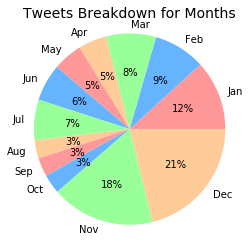

### What is the percentage of True First Predictions by Algorithm at 95% confidence interval?

Algorithm is predicting the true breed 72.37% of times at 95% confodence interval.

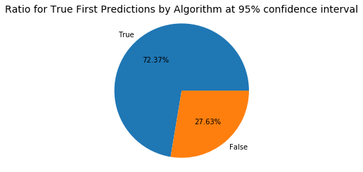

### False Predictions regardless of confidence interval:

If we totally ignore the confidence interval, False predictions are alomost same.

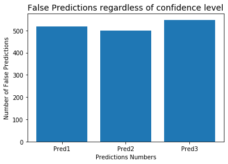